[← Volver a Día 1](https://valentinzarate.github.io/taller_mov/tema_1/tema1.html)

# Datos, Objetos y Formatos

# Tipos de datos y objetos

Lo primero que hay que repasar antes de arrancar con todo son los tipos de datos, al menos los más comunes, que se usan en ecología de movimientos. Lógicamemente, en la estrucutra básica de las tablas cada fila suele representar una observación conformada al menos por tres columnas: latitud, longitud (u otras variantes) y tiempo. Sin embargo, es muy común que los formatos varien bastante entre dispositivos, por lo que como paso inicial debemos explorar y estandarizar estos tres elementos.

Si ya vimos que una trayectoria puede representarse como un número complejo
$$z_t = x_t + i y_t,$$
entonces los datos observados (coordenadas y tiempo) son la base para calcular cualquier métrica de resumen (1) que luego son aplicadas en análisis más complejos.

(
$$\Delta z_t = z_t - z_{t-1}, \quad d_t
= |\Delta z_t|, \quad v_t = \frac{d_t}{\Delta t}.$$
)

## Tipos de objetos en R

Vamos de adelante para atrás. Antes de entrar en el formato de cada columna, importa el tipo de objeto completo donde estan guardados los datos. Lo explico en este orden porque si no tenemos conocimiento de qué tipo de objeto contiene los datos (y cómo operar con dicho objeto) va a ser dificil formatear el dato en sí.

- **Vectores atómicos**: contienen elementos de un único tipo, por ejemplo `numeric`, `character` o `logical`. Son la unidad básica sobre la que se construyen muchas otras estructuras en R.
- **matrix**: estructura bidimensional en la que todos los elementos deben ser del mismo tipo. Es útil cuando trabajamos con datos numéricos organizados en filas y columnas.
- **list**: contenedor flexible que puede almacenar objetos de distinto tipo, tamaño o estructura. Muchas funciones en R devuelven listas porque permiten guardar varios resultados juntos.
- **data.frame**: tabla clásica de R, donde cada columna puede tener una clase distinta. Es uno de los formatos más comunes para trabajar con datos tabulares.
- **tibble**: versión moderna de `data.frame`, más cómoda para imprimir y manipular, especialmente dentro del ecosistema `tidyverse`.
- **sf**: objeto tabular que extiende a `data.frame` o `tibble` incorporando una columna de geometría espacial. Es propio del paquete `sf` y permite integrar datos espaciales de manera muy flexible con muchas herramientas de análisis y visualización. En vez de ser un data.frame “base” conformado por una lista de vectores atomicos de misma longiud, sf es una data.frame pero con una columna especial tipo sfc, después la vemos bien.

Además de estas estructuras generales, existen clases más específicas creadas por paquetes particulares. Por ejemplo, en ecología del movimiento es común encontrarse con objetos como `track_xyt` del paquete `amt`, `Move` o `MoveStack` del paquete `move` (de [**Movebank**](https://www.movebank.org)), objetos `telemetry` de `ctmm`, o estructuras usadas por `momentuHMM` para ajustar modelos ocultos de Markov. En la mayoría de los casos, estas clases especializadas se apoyan en estructuras más generales como listas, `data.frame`s o tibbles, pero agregan reglas, atributos y métodos propios que facilitan análisis específicos; en general son fácilmente reversibles a data.frames.

Antes de entrar en análisis más puntuales, vamos a trabajar principalmente con las estructuras de datos de uso más general (las de arriba), porque entender esa base hace mucho más sencillo después interpretar y manipular objetos más especializados.

```r
v_num <- c(1.2, 3.4, 5.6)              # vector atómico numeric
v_chr <- c("A01", "A02", "A03")        # vector atómico character
m1 <- matrix(1:6, nrow = 3)            # matriz
lst <- list(ids = v_chr, coords = m1)  # lista
df1 <- data.frame(id = v_chr, height = v_num)

class(v_num); class(m1); class(lst); class(df1)
```

```
## [1] "numeric"
```

```
## [1] "matrix" "array"
```

```
## [1] "list"
```

```
## [1] "data.frame"
```

## Tipos de datos a nivel de columna

En una base de datos de movimiento, cada columna suele cumplir una función específica. Definir correctamente su tipo es importante porque muchas operaciones dependen de eso: ordenar observaciones, calcular intervalos de tiempo, filtrar individuos o estimar distancias y velocidades.

Para empezar, vamos a trabajar con una estructura mínima de cuatro columnas: `id`, `timestamp`, `lon` y `lat`. Cada una representa un tipo de dato distinto.

- **`id` (character)**: identifica al individuo o dispositivo. Es texto porque no se usa para calcular, sino para agrupar y filtrar.
- **`timestamp` (POSIXct)**: fecha y hora de cada observación. Es clave para ordenar los datos y calcular intervalos de tiempo entre registros.
- **`lon` y `lat` (numeric)**: coordenadas geográficas. Son variables continuas que permiten calcular distancias, velocidades y trayectorias.

Con solo estas cuatro columnas ya es posible reconstruir trayectorias y calcular métricas básicas del movimiento. Más adelante vamos a transformar `timestamp` al formato adecuado y a trabajar cada tipo de dato por separado para entender cómo se comporta en los análisis y que cosas hay que tener en cuenta.

```r
library(dplyr)
library(tibble)

mov_df <- tibble(
  id = c(
    rep("A01", 12),
    rep("A02", 12)
  ),

  timestamp_chr = c(

    "2026-01-15 08:00:00","2026-01-15 08:10:00","2026-01-15 08:20:00","2026-01-15 08:30:00",
    "2026-01-15 08:40:00","2026-01-15 08:50:00","2026-01-15 09:00:00","2026-01-15 09:10:00",
    "2026-01-15 09:20:00","2026-01-15 09:30:00","2026-01-15 09:40:00","2026-01-15 09:50:00",


    "2026-01-15 08:00:00","2026-01-15 08:15:00","2026-01-15 08:30:00","2026-01-15 08:45:00",
    "2026-01-15 09:00:00","2026-01-15 09:15:00","2026-01-15 09:30:00","2026-01-15 09:45:00",
    "2026-01-15 10:00:00","2026-01-15 10:15:00","2026-01-15 10:30:00","2026-01-15 10:45:00"
  ),

  lon = c(

    -54.5700,-54.5710,-54.5720,-54.5730,
    -54.5745,-54.5760,-54.5775,-54.5790,
    -54.5805,-54.5820,-54.5835,-54.5850,


    -54.5200,-54.5210,-54.5225,-54.5235,
    -54.5250,-54.5265,-54.5280,-54.5290,
    -54.5305,-54.5320,-54.5335,-54.5350
  ),

  lat = c(

    -25.6000,-25.5995,-25.5990,-25.5985,
    -25.5980,-25.5975,-25.5970,-25.5965,
    -25.5960,-25.5955,-25.5950,-25.5945,


    -25.6500,-25.6510,-25.6520,-25.6535,
    -25.6550,-25.6560,-25.6575,-25.6590,
    -25.6600,-25.6615,-25.6630,-25.6645
  )
)

mov_df
```

| id | timestamp_chr | lon | lat |
| --- | --- | --- | --- |
| A01 | 2026-01-15 08:00:00 | -54.5700 | -25.6000 |
| A01 | 2026-01-15 08:10:00 | -54.5710 | -25.5995 |
| A01 | 2026-01-15 08:20:00 | -54.5720 | -25.5990 |
| A01 | 2026-01-15 08:30:00 | -54.5730 | -25.5985 |
| A01 | 2026-01-15 08:40:00 | -54.5745 | -25.5980 |
| A01 | 2026-01-15 08:50:00 | -54.5760 | -25.5975 |
| A01 | 2026-01-15 09:00:00 | -54.5775 | -25.5970 |
| A01 | 2026-01-15 09:10:00 | -54.5790 | -25.5965 |
| A01 | 2026-01-15 09:20:00 | -54.5805 | -25.5960 |
| A01 | 2026-01-15 09:30:00 | -54.5820 | -25.5955 |

[output cut: 14 more lines]

# Tiempo y Espacil

## Formato temporal

La columna de tiempo suele ser un problema generalizado. Muchas veces es registrada con formatos incompatibles con paquetes de movimiento (y otros análisis espaciales). Además del formato per se, un error común es mezclar zonas horarias o trabajar con texto sin convertir a tiempo real.

**Tiempo: texto a POSIXct**

El problema del ejemplo de arriba es que `timestamp_chr` está como texto (`character`), no como tiempo real. Esto es común, la otra es que este fecha (DD/MM/YYYY) y la hora (HH:MM:SSSS) en columnas diferentes, e inclusive con variaciones o mezclas de formatos. Para análisis temporal en R, necesitamos convertirlo a `POSIXct` y con un formato específico.

**¿Qué es POSIXct?**

`POSIXct` es una clase de dato ‘fecha-hora’ en R basada en el estándar POSIX (Portable Operating System Interface). En la práctica, guarda el tiempo como “segundos desde el origen”:
$$\text{1970-01-01 00:00:00 UTC}$$
(esa fecha la van a ver muchas veces). Eso permite operar fácilmente… restar tiempos, ordenar, agrupar por intervalos y calcular duraciones sin ambigüedades.

**La zona horaria (tz)**

Con datos tipo POSIXct es sencillo establecer la zona horaria de los datos, algo que puede ser critico para análisis como patrones diarios de actividad, dormideros, ritmos circadianos, etc. La misma hora escrita como texto puede representar instantes distintos si cambia la zona horaria. Si no definimos `tz`, podemos introducir errores en `t`, velocidad y sincronización entre individuos/dispositivos.

A nivel físico, lo que importa para el movimiento es el **tiempo transcurrido real** entre dos posiciones, no la “hora escrita” en un reloj local. La Tierra rota 360° en 24 horas (aprox. 15° por hora), por eso distintos meridianos tienen distinto mediodía solar y las sociedades definieron zonas horarias para coordinar esa diferencia.

Entonces, un texto como `“2026-01-15 08:00:00”` **sin tz** no identifica un instante único: puede ser 08:00 en Buenos Aires, en Santiago o en UTC, y cada caso representa momentos distintos en la línea temporal global. En análisis de movimiento, esa ambigüedad se traduce en errores directos en intervalos y métricas derivadas.

Por eso conviene definir `tz` explícitamente al convertir. Abajo usamos una forma práctica para asignar la zona horaria desde coordenadas con `lutz::tz_lookup_coords()`. Se necesita el paquete lutz

Algunos ejemplos… por suerte la funcion base de R as.POSIXct() es bastante potente y reconoce formatos típics y los traduce al adecuado.

```r
# el de arriba, el más fácil

mov_df$timestamp_utc <- as.POSIXct(
  mov_df$timestamp_chr,
  format = "%Y-%m-%d %H:%M:%S",
  tz = "UTC")
```

Otro caso común

Ejemplo 2: fecha y hora en columnas separadas

```r
mov_df2 <- tibble::tibble(
  id = c("A01","A01","A02"),
  fecha = c("15/01/2026","15/01/2026","15/01/2026"),
  hora  = c("08:00:00","08:15:00","08:20:00"),
  lon = c(-58.3816, -58.3821, -58.4500),
  lat = c(-34.6037, -34.6030, -34.6200)
)

mov_df2$timestamp <- as.POSIXct(
  paste(mov_df2$fecha, mov_df2$hora),
  format = "%d/%m/%Y %H:%M:%S",
  tz = "UTC"
)
```

Ejemplo 3: formato día-mes-año con guiones

```r
mov_df3 <- tibble::tibble(
  id = c("A01","A01","A02"),
  timestamp_chr = c(
    "15-01-2026 08:00:00",
    "15-01-2026 08:15:00",
    "15-01-2026 08:20:00"
  ),
  lon = c(-58.3816, -58.3821, -58.4500),
  lat = c(-34.6037, -34.6030, -34.6200)
)

mov_df3$timestamp <- as.POSIXct(
  mov_df3$timestamp_chr,
  format = "%d-%m-%Y %H:%M:%S",
  tz = "UTC"
)
```

Ejemplo 4: formato con mes/día/año

```r
mov_df4 <- tibble::tibble(
  id = c("A01","A01","A02"),
  timestamp_chr = c(
    "01/15/2026 08:00:00",
    "01/15/2026 08:15:00",
    "01/15/2026 08:20:00"
  ),
  lon = c(-58.3816, -58.3821, -58.4500),
  lat = c(-34.6037, -34.6030, -34.6200)
)

mov_df4$timestamp <- as.POSIXct(
  mov_df4$timestamp_chr,
  format = "%m/%d/%Y %H:%M:%S",
  tz = "UTC"
)
```

Ejemplo 5: con separador T típico de ISO 8601

```r
mov_df5 <- tibble::tibble(
  id = c("A01","A01","A02"),
  timestamp_chr = c(
    "2026-01-15T08:00:00",
    "2026-01-15T08:15:00",
    "2026-01-15T08:20:00"
  ),
  lon = c(-58.3816, -58.3821, -58.4500),
  lat = c(-34.6037, -34.6030, -34.6200)
)

mov_df5$timestamp <- as.POSIXct(
  mov_df5$timestamp_chr,
  format = "%Y-%m-%dT%H:%M:%S",
  tz = "UTC"
)
```

Alternativamente el paquete `lubridate` tiene funciones que van muy bien también y no requieren explicitar el `format=`, pero a veces puede pifiarle.

```r
mov_df$timestamp <- lubridate::ymd_hms(mov_df$timestamp_chr, tz = "UTC")
mov_df4$timestamp <- lubridate::mdy_hms(mov_df4$timestamp_chr, tz = "UTC")
```

**¿UTC?**

Si asingo “UTC”, entonces se interpretá estos textos como hora en **Tiempo Universal Coordinado** (UTC, offset +00:00)”. Entonces `“2026-01-15 08:00:00”` pasa a ser el instante global **08:00 UTC**.

UTC está basado en el meridiano de Greenwich (0° longitud), en el Reino Unido. Es equivalente al antiguo GMT (*Greenwich Mean Time*), pero más preciso.

Eso es correcto **solo si** el reloj/dispositivo ya guardó los datos en UTC. Si ese texto era hora local (por ejemplo Buenos Aires), usar `tz = “UTC”` desplaza el instante real y mete error en `t`.

`lutz::tz_lookup_coords()` infiere la zona horaria real desde lat/lon (por ejemplo `“America/Argentina/Buenos_Aires”`), en vez de asumir una fija. Eso ayuda cuando el archivo viene en hora local y no trae metadatos claros (muy común).

**`tz = lutz::tz_lookup_coords(…)`**: mejor si el timestamp está en hora local y querés asignar la zona correcta según ubicación.

No es que `lutz` sea “siempre mejor”; es mejor cuando **no conocés** la zona horaria del registro. Si conocés el protocolo del dispositivo y dice UTC, usá UTC directo.

```r
tz_local <- lutz::tz_lookup_coords(
  lat = mov_df$lat[1],
  lon = mov_df$lon[1],
  method = "accurate"
)

mov_df$timestamp_local_interp <- as.POSIXct(
  mov_df$timestamp_chr,
  format = "%Y-%m-%d %H:%M:%S",
  tz = tz_local
)
```

```r
mov_df$diff_hours <- as.numeric(
  difftime(mov_df$timestamp_local_interp, mov_df$timestamp_utc, units = "hours")
)

mov_df[, c("timestamp_chr", "timestamp_utc", "timestamp_local_interp", "diff_hours")]
```

| timestamp_chr | timestamp_utc | timestamp_local_interp | diff_hours |
| --- | --- | --- | --- |
| 2026-01-15 08:00:00 | 2026-01-15 08:00:00 | 2026-01-15 08:00:00 | 3 |
| 2026-01-15 08:10:00 | 2026-01-15 08:10:00 | 2026-01-15 08:10:00 | 3 |
| 2026-01-15 08:20:00 | 2026-01-15 08:20:00 | 2026-01-15 08:20:00 | 3 |
| 2026-01-15 08:30:00 | 2026-01-15 08:30:00 | 2026-01-15 08:30:00 | 3 |
| 2026-01-15 08:40:00 | 2026-01-15 08:40:00 | 2026-01-15 08:40:00 | 3 |
| 2026-01-15 08:50:00 | 2026-01-15 08:50:00 | 2026-01-15 08:50:00 | 3 |
| 2026-01-15 09:00:00 | 2026-01-15 09:00:00 | 2026-01-15 09:00:00 | 3 |
| 2026-01-15 09:10:00 | 2026-01-15 09:10:00 | 2026-01-15 09:10:00 | 3 |
| 2026-01-15 09:20:00 | 2026-01-15 09:20:00 | 2026-01-15 09:20:00 | 3 |
| 2026-01-15 09:30:00 | 2026-01-15 09:30:00 | 2026-01-15 09:30:00 | 3 |

[output cut: 14 more lines]

**¿Por qué la diferencia da 3 horas?**

Esto pasa porque una fecha-hora en `POSIXct` tiene dos componentes conceptualmente distintas:

- un **instante real** en la línea temporal;
- una **zona horaria** usada para mostrar ese instante como hora de reloj.

En tu ejemplo, ambas columnas se imprimen como

```
2026-01-15
08:00:00
```

, pero no representan el mismo instante absoluto. Lo que ocurre es que cada una está siendo mostrada con su propia interpretación horaria.

Dicho de otra forma: el texto visible puede coincidir, pero el “punto real” en el tiempo no coincide. Por eso, cuando restás ambas columnas, aparece una diferencia de **3 horas**.

Si escribimos el mismo reloj
$$\text{"2026-01-15 08:00:00"}$$
y lo interpretamos una vez como UTC y otra vez como hora de Buenos Aires, obtenemos dos instantes distintos:

Como Buenos Aires está a 3 horas de UTC en ese caso, esas dos interpretaciones quedan separadas por:

$$3 \text{ horas}.$$

Tus dos columnas no son “la misma hora escrita de dos maneras”, sino **dos hipótesis distintas sobre qué quiso decir el texto original**.

- `timestamp_utc`: “este texto ya estaba en UTC”.
- `timestamp_local_interp`: “este texto estaba escrito en hora local”.

Como ambas parten del mismo texto, el reloj mostrado puede verse igual. Pero como fueron interpretadas en zonas distintas, el instante absoluto cambia.

```r
attr(mov_df$timestamp_utc, "tzone")
```

```
## [1] "UTC"
```

```r
attr(mov_df$timestamp_local_interp, "tzone")
```

```
## [1] "America/Argentina/Cordoba"
```

### ¿Qué hacer en la práctica?

Hay tres estrategias, ordenadas de mejor a peor:

- **1. Buscar información externa** (recomendado)
  - metadata del dispositivo
  - manual del collar o GPS
  - documentación del proyecto
- **2. Inferir con contexto**
  - ubicación geográfica
  - patrones diarios (día/noche)
  - consistencia entre individuos
- **3. Asumir explícitamente (último recurso)**
  - por ejemplo: asumir hora local
  - o asumir UTC

**Es importante documentar la decisión**

Si no hay metadatos y tomamos una decisión, debemos dejarlo explícito:

**“Los timestamps fueron interpretados como hora local basada en la ubicación de los registros.”**

o

**“Los timestamps fueron asumidos como UTC debido a falta de información adicional.”**

### Consecuencia en el análisis

Una mala asignación de zona horaria no cambia las coordenadas, pero sí afecta:

- intervalos de tiempo
  $$\Delta t$$
- velocidad
- ritmos diarios
- sincronización entre individuos

## Latitud y longitud

Cuando hablamos de números complejos representamos posiciones en un plano bidimensional usando coordenadas cartesianas, donde cada punto se escribe como
$$(x, y)$$
o, de forma equivalente, como un número complejo:
$$z = x + iy.$$

Ese enfoque supone que estamos trabajando en un **plano euclidiano**, donde las distancias, direcciones y operaciones algebraicas son directas y tienen una interpretación geométrica simple…

Sin embargo, cuando trabajamos con datos reales de movimiento (por ejemplo GPS), las coordenadas no vienen en ese formato, sino como **latitud** y **longitud**.

### ¿Qué son latitud y longitud?

Las coordenadas geográficas describen posiciones sobre la superficie de la Tierra, que es aproximadamente esférica. En este sistema:

- **Latitud**: ángulo respecto al ecuador (norte-sur).
- **Longitud**: ángulo respecto al meridiano de Greenwich (este-oeste).

Por lo tanto, latitud y longitud no son distancias lineales, sino **ángulos**, generalmente expresados en grados.

Esto significa que una observación como:
$$(-58.38,\ -34.60)$$
no representa un punto en un plano cartesiano, sino una posición angular sobre la superficie de la Tierra.

Las operaciones que vimos antes para trayectorias en el plano:

$$\Delta z_t = z_t - z_{t-1}, \quad d_t = |\Delta z_t|$$

suponen un espacio euclidiano donde las diferencias de coordenadas representan desplazamientos lineales. Pero en coordenadas geográficas esto **no es estrictamente válido**.

- La distancia asociada a 1° de longitud depende de la latitud.
- Las trayectorias “rectas” en el mapa no son rectas sobre la esfera.
- Las diferencias simples de coordenadas no representan desplazamientos métricos reales.

Por eso, aunque lat/lon es excelente para ubicar posiciones globalmente y hacer mapas, no es adecuado para hacer cálculos directos de distancia, velocidad o desplazamiento usando geometría plana.

### Sistema WGS84 y EPSG:4326

El sistema más común para datos GPS (y muchas constalaciones de satelites) es **WGS84**, que define un modelo de la Tierra y un sistema de coordenadas geográficas.

### Sistema de referencia y código EPSG

Para interpretar coordenadas no alcanza con los valores (lat, lon), también necesitamos saber **en qué sistema están definidas**. Eso es el **CRS** (Coordinate Reference System).

**WGS84** es el sistema global usado por GPS (define la forma de la Tierra y cómo ubicar puntos).

**EPSG** es un sistema de códigos que identifican CRS en software.

Por ejemplo:

$$\text{EPSG:4326}$$

significa: coordenadas geográficas (lat/lon en grados) bajo WGS84.

Cuando usamos `crs = 4326` en `sf`, estamos diciendo cómo interpretar las coordenadas, no transformándolas. Más adelante veremos otros códigos, como UTM (por ejemplo `EPSG:32721`), donde las unidades pasan a ser metros.

### Objeto espacial en R

Podemos convertir un `data.frame` con columnas de longitud y latitud en un objeto espacial con `sf`.

1. De tabla a sf en lon/lat (WGS84)

```r
require(sf)
mov_sf <- st_as_sf(mov_df, coords = c("lon", "lat"), crs = 4326, remove = FALSE)
```

este objeto se usan mucho y son fáciles de manejar. No son nada raro, aunque aparece como clase Simple Features, son una data.frame y soportan casi todas las funciones aplicables a una df o un tibble. Detalle `remove = FALSE` conserva las columans lat y lon, en caso contrario las elimina por default.

```r
class(mov_sf)
```

```
## [1] "sf"         "tbl_df"     "tbl"        "data.frame"
```

```r
mov_sf$geometry
```

```
## Geometry set for 24 features
## Geometry type: POINT
## Dimension:     XY
## Bounding box:  xmin: -54.585 ymin: -25.6645 xmax: -54.52 ymax: -25.5945
## Geodetic CRS:  WGS 84
## First 5 geometries:
```

```r
class(mov_sf$geometry)
```

```
## [1] "sfc_POINT" "sfc"
```

```r
class(mov_sf$lat)
```

```
## [1] "numeric"
```

Acá vemos que la columna nueva es Simple Feature Column, a diferencia de las otras que son vectores. sfc parece horrible al principio, pero es una lista de muchas geometrias

```r
str(mov_sf$geometry)
```

```
## sfc_POINT of length 24; first list element:  'XY' num [1:2] -54.6 -25.6
```

```r
mov_sf$geometry
```

```
## Geometry set for 24 features
## Geometry type: POINT
## Dimension:     XY
## Bounding box:  xmin: -54.585 ymin: -25.6645 xmax: -54.52 ymax: -25.5945
## Geodetic CRS:  WGS 84
## First 5 geometries:
```

```r
unclass(mov_sf$geometry[[1]])
```

```
## [1] -54.57 -25.60
```

```r
mov_sf_lista <- as.list(mov_sf$geometry)
```

Para que se entienda mejor vamos a “aplanar” la lista a un DF.

```r
mov_sf_lista <- as.list(mov_sf$geometry)

coords_df <- purrr::map_dfr(
  mov_sf_lista,
  ~ as.data.frame(t(unclass(.x)))
)

colnames(coords_df) <- c("X", "Y")

# metadata global de la columna geometry
geom_type <- as.character(unique(st_geometry_type(mov_sf)))
crs_name  <- st_crs(mov_sf)$Name
crs_epsg  <- st_crs(mov_sf)$epsg
bbox_vals <- st_bbox(mov_sf)

coords_df$geometry_type <- geom_type
coords_df$dimension <- class(mov_sf$geometry)[1]   # sfc_POINT
coords_df$crs_name <- crs_name
coords_df$crs_epsg <- crs_epsg
coords_df$bbox_xmin <- bbox_vals["xmin"]
coords_df$bbox_ymin <- bbox_vals["ymin"]
coords_df$bbox_xmax <- bbox_vals["xmax"]
coords_df$bbox_ymax <- bbox_vals["ymax"]

coords_df
```

| X | Y | geometry_type | dimension | crs_name | crs_epsg | bbox_xmin | bbox_ymin | bbox_xmax | bbox_ymax |
| --- | --- | --- | --- | --- | --- | --- | --- | --- | --- |
| -54.5700 | -25.6000 | POINT | sfc_POINT | WGS 84 | 4326 | -54.585 | -25.6645 | -54.52 | -25.5945 |
| -54.5710 | -25.5995 | POINT | sfc_POINT | WGS 84 | 4326 | -54.585 | -25.6645 | -54.52 | -25.5945 |
| -54.5720 | -25.5990 | POINT | sfc_POINT | WGS 84 | 4326 | -54.585 | -25.6645 | -54.52 | -25.5945 |
| -54.5730 | -25.5985 | POINT | sfc_POINT | WGS 84 | 4326 | -54.585 | -25.6645 | -54.52 | -25.5945 |
| -54.5745 | -25.5980 | POINT | sfc_POINT | WGS 84 | 4326 | -54.585 | -25.6645 | -54.52 | -25.5945 |
| -54.5760 | -25.5975 | POINT | sfc_POINT | WGS 84 | 4326 | -54.585 | -25.6645 | -54.52 | -25.5945 |
| -54.5775 | -25.5970 | POINT | sfc_POINT | WGS 84 | 4326 | -54.585 | -25.6645 | -54.52 | -25.5945 |
| -54.5790 | -25.5965 | POINT | sfc_POINT | WGS 84 | 4326 | -54.585 | -25.6645 | -54.52 | -25.5945 |
| -54.5805 | -25.5960 | POINT | sfc_POINT | WGS 84 | 4326 | -54.585 | -25.6645 | -54.52 | -25.5945 |
| -54.5820 | -25.5955 | POINT | sfc_POINT | WGS 84 | 4326 | -54.585 | -25.6645 | -54.52 | -25.5945 |

[output cut: 14 more lines]

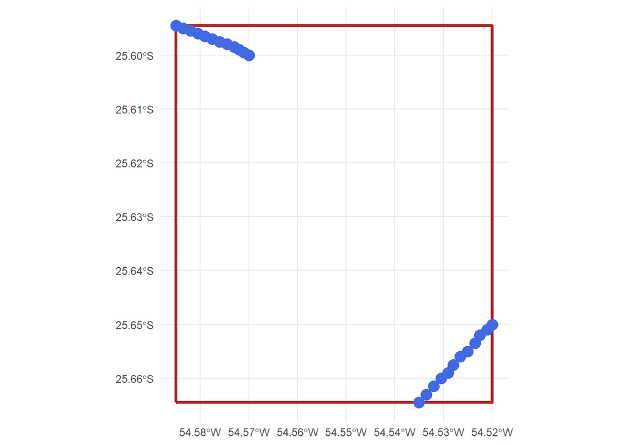

```r
library(ggplot2)

bbox_poly <- st_as_sfc(st_bbox(mov_sf))

ggplot() +
  geom_sf(data = bbox_poly, fill = NA, color = "firebrick", linewidth = 1.2) +
  geom_sf(data = mov_sf, color = "royalblue", size = 4) +
  theme_minimal()
```

Mejor aún

```r
mapview::mapview(mov_sf, coords = c("lat", "lon")) +
  mapview::mapview(
    bbox_poly,
    col.regions = NA,
    alpha.regions = 0,
    color = "firebrick",
    lwd = 2)
```

[interactive chart not shown]

### Shapefiles “simples”

Una forma útil de pensar un objeto `sf` es como una versión moderna y cómoda, dentro de R, de un conjunto de datos espaciales vectoriales.

Un **shapefile** no es un único archivo, sino un conjunto de archivos que guardan distintas partes de la información espacial:

- `.shp`: la geometría
- `.dbf`: la tabla de atributos
- `.shx`: un índice espacial
- `.prj`: el sistema de referencia de coordenadas

En cambio, un objeto `sf` reúne todo eso dentro de una sola estructura en R:

- las columnas comunes guardan los atributos
- la columna `geometry` guarda las geometrías
- el CRS, el *bounding box* y otra metadata espacial quedan asociados al objeto

Por eso, un `sf` puede verse como el equivalente en memoria de un shapefile, pero más simple de manipular y más integrado con la lógica de tablas de R.

Esto también explica por qué es tan fácil exportar un objeto `sf` a formatos espaciales como `.shp`: la información geométrica y sus metadatos ya están organizados dentro del objeto, aunque en R no aparezcan como archivos separados. Esto va a ser clave cuando se quiera compatibilizar los puntos en el espacio (o poligonos) del animal estudiado con elementros del paisaje, ya sea en “rasters” o en otros “shapefiles”.

## Proyección UTM

Enteonces, el SF no cambia los datos, solamente a cada fila le asigna una geometría asociada (un punto en la superficie terrestre) y un sistema de referencia explícito.

Aunque ahora tenemos un objeto espacial, seguimos en coordenadas geográficas (angulares). Eso implica que todavía no estamos en un plano euclidiano donde podamos aplicar directamente la lógica de:

$$z = x + iy$$

ni calcular distancias como si estuviéramos en un sistema cartesiano simple.

Para conectar con lo que vimos de números complejos y trabajar con desplazamientos de forma consistente, necesitamos pasar de coordenadas angulares a coordenadas métricas en un plano.

Eso se logra mediante una **proyección cartográfica**.

Hasta ahora vimos que las coordenadas geográficas (latitud y longitud) representan posiciones sobre una superficie curva. Eso es ideal para ubicar puntos globalmente, pero no para hacer cálculos simples en un plano.

Para poder trabajar como en geometría analítica en el mundito de los números complejos
$$z = x + iy$$
tenemos que aplastar esa curva. Una de las proyecciones más utilizadas en ecología es el sistema
$$\text{UTM
(Universal Transverse Mercator)}$$
(Pero hay varios más, como Albers, Robinson..)

**¿Cómo funciona UTM?**

El sistema UTM divide la Tierra en **60 zonas longitudinales**, cada una de:

- 6° de ancho en longitud
- extendidas en dirección norte-sur

Cada una de estas zonas se proyecta de forma independiente en un plano. Esto permite que, dentro de cada zona, la distorsión sea relativamente baja.

En términos prácticos: en lugar de trabajar sobre una esfera, trabajamos sobre muchos planos locales.

**Un sistema cartesiano en cada zona**

Dentro de cada zona UTM, se define un sistema de coordenadas muy similar al plano cartesiano:

- **X (Easting)**: dirección este-oeste
- **Y (Northing)**: dirección norte-sur

La diferencia con el plano matemático clásico es que se utilizan **orígenes desplazados** para evitar valores negativos.

**Origen falso (false origin)**

En UTM, el sistema no usa el origen (0,0) tradicional. En cambio:

- El meridiano central de cada zona se define como:
  $$X = 500{,}000 \ \text{m}$$
- En el hemisferio sur, el ecuador se define como:
  $$Y = 10{,}000{,}000 \ \text{m}$$

Esto garantiza que todas las coordenadas sean positivas, lo cual simplifica cálculos y almacenamiento.

### Interpretación geométrica

Dentro de una zona UTM, podemos pensar cada punto como:

$$(x, y) \quad \text{en metros}$$

y, por lo tanto, como un número complejo:

$$z = x + iy$$

Ahora sí, las diferencias entre puntos representan desplazamientos reales:

$$\Delta z = z_t - z_{t-1}$$

y su módulo representa distancia en metros:

$$|\Delta z|$$

Esto conecta directamente con todo lo que vimos antes sobre trayectorias y movimiento.

UTM permite pasar de:

- coordenadas angulares (lat/lon)
- a coordenadas métricas en un plano local

con baja distorsión dentro de cada zona.

```r
library(sf)
library(mapview)

# Polígonos de dos zonas UTM en coordenadas geográficas
coords_polygon_20 <- matrix(c(
  -60, 0,
  -54, 0,
  -54, -90,
  -60, -90,
  -60, 0
), ncol = 2, byrow = TRUE)

coords_polygon_21 <- matrix(c(
  -54, 0,
  -48, 0,
  -48, -90,
  -54, -90,
  -54, 0
), ncol = 2, byrow = TRUE)

polygon_20 <- st_polygon(list(coords_polygon_20))
polygon_21 <- st_polygon(list(coords_polygon_21))

polygon_sf_20 <- st_sfc(polygon_20, crs = 4326)
polygon_sf_21 <- st_sfc(polygon_21, crs = 4326)

# Transformación a UTM
polygon_utm_20 <- st_transform(polygon_sf_20, 32720)
polygon_utm_21 <- st_transform(polygon_sf_21, 32721)

polygons_utm_20 <- st_sf(geometry = polygon_utm_20, zone = "Zona 20S")
polygons_utm_21 <- st_sf(geometry = polygon_utm_21, zone = "Zona 21S")

mapview(polygons_utm_20, col.regions = "blue") +
  mapview(polygons_utm_21, col.regions = "red")
```

[interactive chart not shown]

Básicamente todos los calculos los hacemos acá

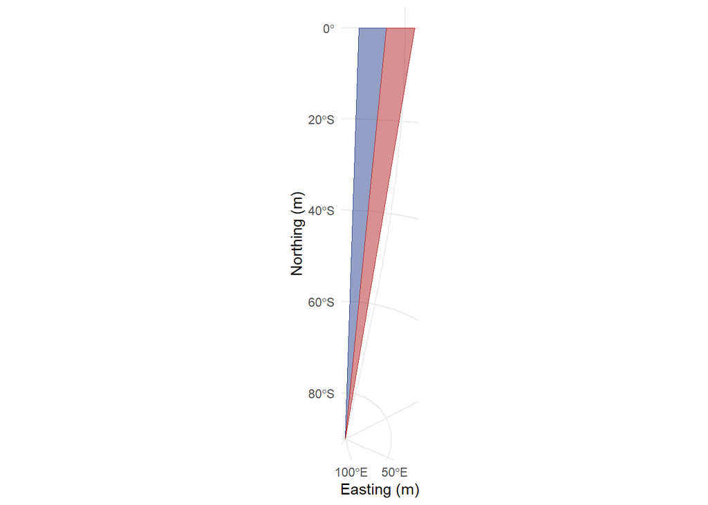

```r
ggplot() +
  geom_sf(data = polygons_utm_20, fill = "royalblue4", alpha = 0.5, color = "royalblue4") +
  geom_sf(data = polygons_utm_21, fill = "firebrick", alpha = 0.5, color = "firebrick") +
  labs(
    x = "Easting (m)",
    y = "Northing (m)"
  ) +
  theme_minimal()
```

### Interpretación del gráfico

En este gráfico estamos viendo cómo dos franjas de la Tierra (definidas en latitud/longitud) se transforman en dos planos distintos.

Cada zona tiene su propio sistema de coordenadas, su propio origen desplazado y su propia geometría.

Esto implica algo muy importante:

- No podemos mezclar directamente coordenadas de distintas zonas UTM.
- El análisis debe hacerse dentro de una misma zona (o reproyectando cuidadosamente).

### Conexión final con movimiento

Una vez que los datos están en UTM:

- las coordenadas están en metros
- las diferencias son desplazamientos reales
- las distancias son euclidianas

y entonces podemos trabajar directamente con:

$$z_t = x_t + i y_t$$

como una representación válida y útil del movimiento en el plano.

## Ejemplo de datos reales: Movebank

Para trabajar con datos reales de ecología de movimientos, una de las plataformas más importantes es **Movebank**.

Movebank es una base de datos global que almacena y distribuye datos de seguimiento de animales, incluyendo trayectorias obtenidas con GPS, sensores y otros dispositivos.

En esta plataforma, investigadores de todo el mundo comparten datos de movimiento de distintas especies, lo que permite estudiar patrones a escala local, regional y global.

### ¿Qué tipo de información contiene?

- posiciones (latitud y longitud)
- tiempo (timestamps)
- identidad del individuo
- variables ambientales o del dispositivo

Es decir, exactamente el tipo de datos que venimos discutiendo:

$$(id,\ t,\ x,\ y)$$

A continuación se muestra una vista general de la distribución global de estudios en Movebank:

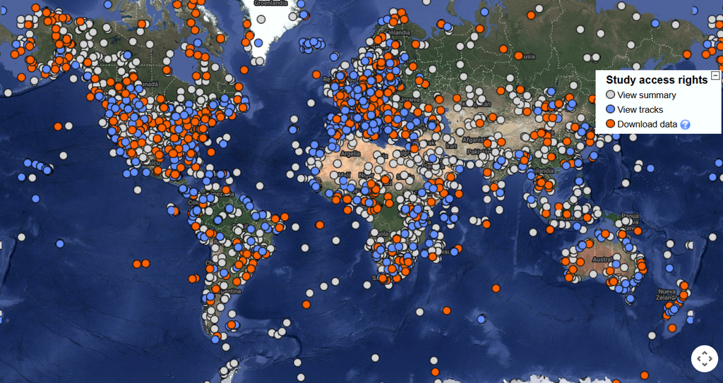

Cada punto representa un estudio o conjunto de datos de seguimiento. Esto nos da una idea de la escala y diversidad de datos disponibles.

### CAso puntual

El estudio que vamos a probar es de Nyctereutes procyonoides en las costas de un pais nordico.

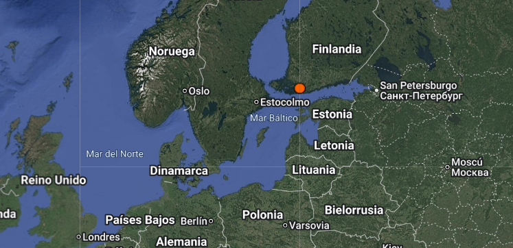

Desde la plataforma uno puede bajar los CSV y otros tipos de archivos, pero una alternativa para no tener que estar llenando la compu de tablas (a veces enormes) es acceder a través del paquete que hicieron.

Antes de cargar uno tiene que identificar el estudio, con el codigo `getMovebankStudies()` uno puede ver los estudios, pero es más fácil de la plataforma. Si el estudio tiene los datos disponibles para usarlos (los naranjita) entonces apretas “Download Data” en la plataforma y aceptas los términos de uso.. una vez hecho eso ya se puede descargar el estudio.

```r
library(move)
login <- movebankLogin(
  username = "valentinzarate",
  password = "Dni35089516!"
)

study <- 4656276921

# descargar datos
dat <- getMovebankData(study = study, login = login)
```

Lo hacemos data.frame

```r
data <- as.data.frame(dat)
```

```r
length(colnames(data))
```

```
## [1] 48
```

48 columnas… vamos a elegir las que nos importan

```r
colnames(data)
```

```
##  [1] "tag_id"                  "sensor_type_id"
##  [3] "gps_hdop"                "location_lat"
##  [5] "location_long"           "timestamp"
##  [7] "update_ts"               "visible"
##  [9] "deployment_id"           "event_id"
## [11] "sensor_type"             "tag_local_identifier"
## [13] "location_long.1"         "location_lat.1"
## [15] "optional"                "sensor"
## [17] "timestamps"              "trackId"
## [19] "animal_birth_hatch_year" "birth_hatch_latitude"
## [21] "birth_hatch_longitude"   "comments"
## [23] "death_comments"          "earliest_date_born"
## [25] "exact_date_of_birth"     "group_id"
## [27] "individual_id"           "latest_date_born"
## [29] "local_identifier"        "marker_id"
## [31] "mates"                   "mortality_date"
## [33] "mortality_latitude"      "mortality_longitude"
## [35] "mortality_type"          "nick_name"
## [37] "offspring"               "parents"
## [39] "ring_id"                 "sex"
## [41] "siblings"                "taxon_canonical_name"
## [43] "timestamp_start"         "timestamp_end"
## [45] "number_of_events"        "number_of_deployments"
## [47] "sensor_type_ids"         "taxon_detail"
```

```r
data <- data |> dplyr::select(individual_id,
                              group_id,
                              tag_id,
                              location_lat,
                              location_long,
                              timestamp)
```

```r
str(data)
```

```
## 'data.frame':    18392 obs. of  6 variables:
##  $ individual_id: num  4.66e+09 4.66e+09 4.66e+09 4.66e+09 4.66e+09 ...
##  $ group_id     : logi  NA NA NA NA NA NA ...
##  $ tag_id       : num  4.66e+09 4.66e+09 4.66e+09 4.66e+09 4.66e+09 ...
##  $ location_lat : num  60.3 60.3 60.3 60.3 60.3 ...
##  $ location_long: num  21.2 21.2 21.2 21.2 21.2 ...
##  $ timestamp    : POSIXct, format: "2022-04-24 21:00:00" "2022-04-24 23:00:00" ...
```

```r
attr(data$timestamp, "tzone")
```

```
## [1] "UTC"
```

vamos a cambiar a la hora local

```r
tz_local <- lutz::tz_lookup_coords(
  lat = data$location_lat[1],
  lon = data$location_long[1],
  method = "accurate"
)

tz_local
```

```
## [1] "Europe/Helsinki"
```

Vamos a hacer una columna nueva y de paso la acortaoms

```r
x_chr <- "2022-04-24 21:00:00"
as.POSIXct(x_chr, tz = "UTC")
```

```
## [1] "2022-04-24 21:00:00 UTC"
```

```r
as.POSIXct(x_chr, tz = "Europe/Helsinki")
```

```
## [1] "2022-04-24 21:00:00 EEST"
```

```r
data$t <- lubridate::with_tz(data$timestamp, tzone = tz_local)
```

```r
head(data.frame(
  utc = format(data$timestamp, tz = "UTC", usetz = TRUE),
  local = format(data$timestamp_local, tz = "Europe/Helsinki", usetz = TRUE)
))
```

|  | utc | local |
| --- | --- | --- |
| 1 | 2022-04-24 21:00:00 UTC | NULL |
| 2 | 2022-04-24 23:00:00 UTC | NULL |
| 3 | 2022-04-25 21:00:00 UTC | NULL |
| 4 | 2022-04-26 17:00:00 UTC | NULL |
| 5 | 2022-04-26 21:00:00 UTC | NULL |
| 6 | 2022-04-28 17:00:00 UTC | NULL |

Claramente tenemos que usar `t`.

Bueno ahora lo mapeamos haciéndolo SF

```r
data_sf <- st_as_sf(
  data,
  coords = c("location_long", "location_lat"),
  crs = 4326)
```

Lo vemos

```r
library(viridis)

mapview(
  data_sf,
  zcol = "tag_id",
  col.regions = turbo(length(unique(data_sf$tag_id)))
)
```

[interactive chart not shown]

mejor hagarramos uno solito

```r
zorro <- data_sf |> filter (tag_id == "4656357092")
mapview(zorro,
        color = "black",
        lwd = 2,
        col.regions = "gold",
        map.types = "Esri.WorldImagery")
```

[interactive chart not shown]

```r
coords <- st_coordinates(zorro)

lon <- coords[,1]
lat <- coords[,2]

zone <- floor((mean(lon) + 180) / 6) + 1

zone
```

```
## [1] 34
```

Esta es la zona de los zorros.. sabemos que está al norte, así que es 6 (sino sería 7). Para transformar es fácil.

```r
zorro_utm <- st_transform(zorro, 32634)

xy <- st_coordinates(zorro_utm)

zorro_utm$X <- xy[,1]
zorro_utm$Y <- xy[,2]

zorro_utm <- st_drop_geometry(zorro_utm)
```

Por las dudas.

```r
zorro_utm <- zorro_utm |>
  dplyr::arrange(t)
```

```r
zorro_utm$step <- seq_len(nrow(zorro_utm))
```

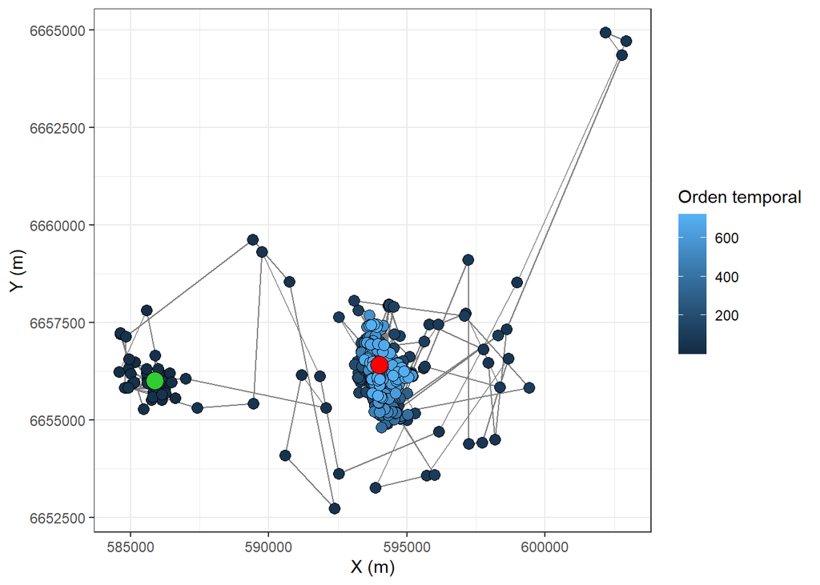

```r
ggplot(zorro_utm, aes(x = X, y = Y)) +
  geom_path(color = "grey50", linewidth = 0.5) +
  geom_point(aes(fill = step), color = "black", shape = 21, size = 3) +
  geom_point(data = zorro_utm[1, ], fill = "limegreen", color = "black", shape = 21, size = 5) +
  geom_point(data = zorro_utm[nrow(zorro_utm), ], fill = "red", color = "black", shape = 21, size = 5) +
  labs(
    x = "X (m)",
    y = "Y (m)",
    fill = "Orden temporal"
  ) +
  theme_bw()
```

Pasos y angulos

```r
zorro_utm$z <- zorro_utm$X + 1i * zorro_utm$Y
```

```r
zorro_utm$dz <- c(NA, diff(zorro_utm$z))

zorro_utm$step <- Mod(zorro_utm$dz)
```

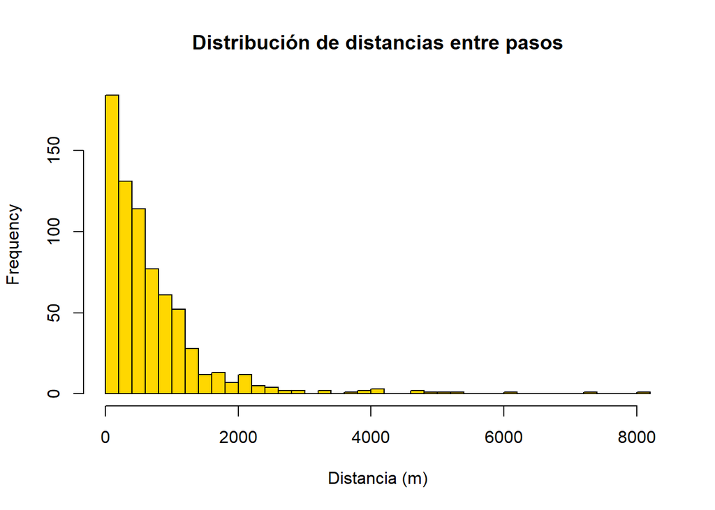

```r
hist(
  zorro_utm$step,
  breaks = 30,
  col = "gold",
  border = "black",
  main = "Distribución de distancias entre pasos",
  xlab = "Distancia (m)"
)
```

```r
zorro_utm$step_direction <- Arg(zorro_utm$dz)
```

```r
zorro_utm$turn_angle <- c(NA, diff(zorro_utm$step_direction))

zorro_utm$theta <- c(NA, diff(zorro_utm$turn_angle))
```

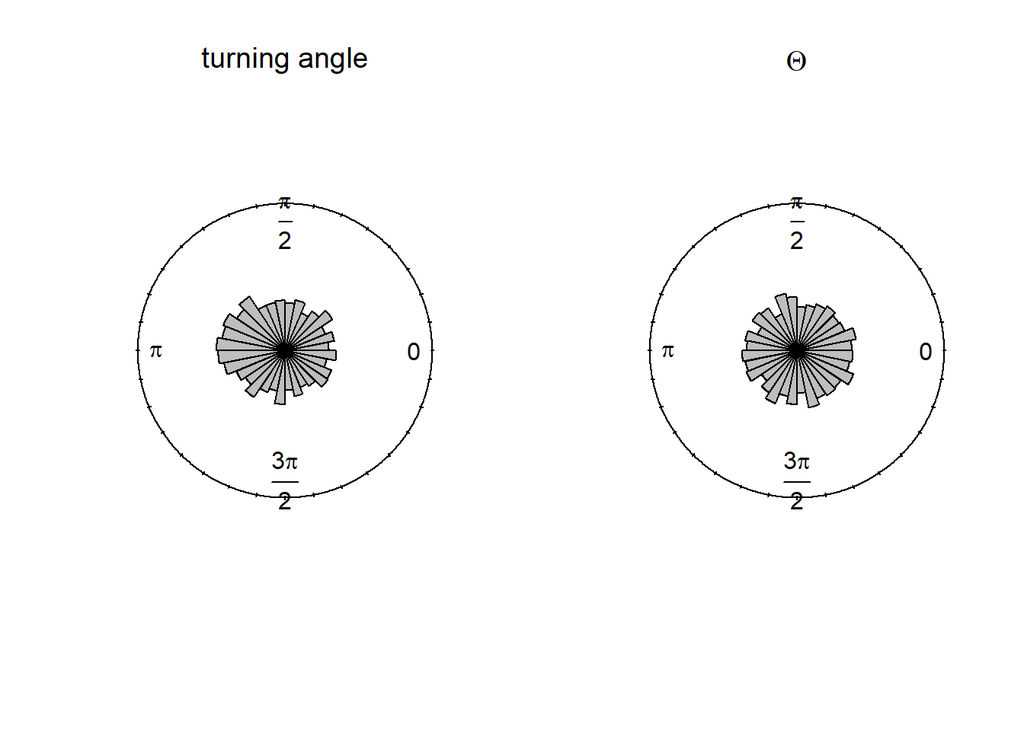

```r
library(circular)

par(mfrow = c(1, 2))

Theta <- circular::as.circular(zorro_utm$theta)
turning_angle <- circular::as.circular(zorro_utm$turn_angle)

circular::rose.diag(turning_angle,
                    bins = 32,
                    col = "grey",
                    prop = 2,
                    main = expression(turning~angle))

circular::rose.diag(Theta,
                    bins = 32,
                    col = "grey",
                    prop = 2,
                    main = expression(Theta))
```

```r
par(mfrow = c(1, 1))
```

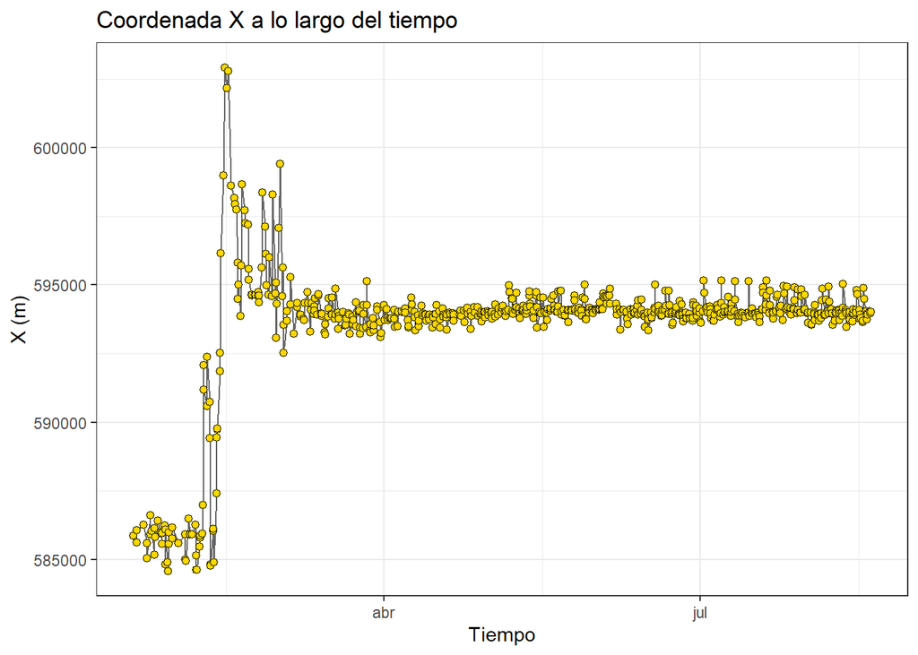

```r
ggplot(zorro_utm, aes(x = t, y = X)) +
  geom_line(color = "grey40", linewidth = 0.4) +
  geom_point(color = "black", fill = "gold", shape = 21, size = 1.8) +
  labs(
    x = "Tiempo",
    y = "X (m)",
    title = "Coordenada X a lo largo del tiempo"
  ) +
  theme_bw()
```

```r
zorro_utm <- zorro_utm |>
  dplyr::arrange(t)

zorro_utm$dt <- c(NA, diff(zorro_utm$t))

zorro_utm$dt_mins <- as.numeric(zorro_utm$dt, units = "mins")

summary(zorro_utm$dt_mins)
```

```
##    Min. 1st Qu.  Median    Mean 3rd Qu.    Max.    NA's
##      30    7200   14400   25480   57600  172800       1
```

```r
table(round(zorro_utm$dt_mins))
```

```
##
##     30     42     50     51     61     85    275   2610   2718   3239   4560
##      1      1      2      1      1      1      1      1      1      1      1
##   7200  10570  14100  14400  21600  27420  28800  29994  30129  34806  43450
##    310      1      1    169     17      1      1      1      1      1      1
##  46980  54840  57240  57600  61500  64800  72000  79200  86400 144000 151200
##      1      1      1    122      1     52      2     14      5      2      1
## 165600 172800
##      1      1
```

```r
library(dplyr)
library(lubridate)

zorro_utm <- zorro_utm |>
  dplyr::arrange(t) |>
  mutate(
    year = year(t),
    month = month(t),
    year_month = floor_date(t, "month")
  )

resumen_mes <- zorro_utm |>
  group_by(year, month) |>
  summarise(
    n_locs = n(),
    dt_mean = mean(dt_mins, na.rm = TRUE),
    dt_sd = sd(dt_mins, na.rm = TRUE),
    dt_min = min(dt_mins, na.rm = TRUE),
    dt_max = max(dt_mins, na.rm = TRUE),
    .groups = "drop")

library(flextable)

flextable(resumen_mes) |>
  autofit() |>
  bg(part = "header", bg = "#0d2a44") |>
  color(part = "header", color = "white") |>
  bold(part = "header") |>
  bg(bg = "#dbe7f5", part = "body") |>
  bg(i = seq(2, nrow(resumen_mes), by = 2), bg = "#c6d8ee", part = "body") |>
  colformat_double(digits = 1) |>
  align(align = "center", part = "all")
```

| year | month | n_locs | dt_mean | dt_sd | dt_min | dt_max |
| --- | --- | --- | --- | --- | --- | --- |
| 2,022.0 | 1.0 | 27 | 43,200.0 | 45,216.9 | 7,200.0 | 165,600.0 |
| 2,022.0 | 2.0 | 77 | 31,698.7 | 29,803.8 | 7,200.0 | 172,800.0 |
| 2,022.0 | 3.0 | 87 | 30,620.7 | 28,501.7 | 85.0 | 86,400.0 |
| 2,022.0 | 4.0 | 89 | 29,123.6 | 29,003.6 | 61.0 | 151,200.0 |
| 2,022.0 | 5.0 | 122 | 21,954.1 | 21,267.2 | 7,200.0 | 64,800.0 |
| 2,022.0 | 6.0 | 122 | 21,245.9 | 23,359.7 | 30.0 | 144,000.0 |
| 2,022.0 | 7.0 | 121 | 22,135.5 | 21,301.2 | 7,200.0 | 64,800.0 |
| 2,022.0 | 8.0 | 76 | 20,747.4 | 20,612.0 | 50.0 | 57,600.0 |

## Función de resumen

Todo esto podemos colapsarlo en una función; en este caso tendría unas pocas dependencias. `lubridate` y `dplyr`.

```r
pepe <- function(df){
  df |> mutate(Month = month(t),
               doy = yday(t),
               hour = hour(t),
               Z = X + 1i*Y,
               Step = c(NA, diff(Z)),
               StepLength = Mod(Step),
               dTime = c(NA, difftime(t[-1],
                                      t[-length(t)],
                                      units = "hours")),
               start = min(t),
               end = max(t),
               Speed = StepLength/dTime,
               Orientation = Arg(Step),
               TurningAngle = c(NA, diff(Orientation))
  )
}

zorro_sum <- pepe(zorro_utm)
zorro_sum
```

| individual_id | group_id | tag_id | timestamp | t | X | Y | step | z | dz | step_direction | turn_angle | theta | dt | dt_mins | year | month | year_month | Month | doy | hour | Z | Step | StepLength | dTime | start | end | Speed | Orientation | TurningAngle |
| --- | --- | --- | --- | --- | --- | --- | --- | --- | --- | --- | --- | --- | --- | --- | --- | --- | --- | --- | --- | --- | --- | --- | --- | --- | --- | --- | --- | --- | --- |
| 4656357091 | NA | 4656357092 | 2022-01-18 15:00:00 | 2022-01-18 17:00:00 | 585878.3 | 6655995 | NaN | 585878.3+6655995i | NA | NA | NA | NA | NA | NA | 2022 | 1 | 2022-01-01 | 1 | 18 | 17 | 585878.3+6655995i | NA | NaN | NA | 2022-01-18 17:00:00 | 2022-08-19 02:00:00 | NaN | NA | NA |
| 4656357091 | NA | 4656357092 | 2022-01-19 15:00:00 | 2022-01-19 17:00:00 | 585608.7 | 6656040 | 273.3010363 | 585608.7+6656040i | -2.696124e+02+ 44.7504804i | 2.97711139 | NA | NA | 86400 | 86400 | 2022 | 1 | 2022-01-01 | 1 | 19 | 17 | 585608.7+6656040i | -2.696124e+02+ 44.7504804i | 273.3010363 | 24.000000000 | 2022-01-18 17:00:00 | 2022-08-19 02:00:00 | 11.3875432 | 2.97711139 | NA |
| 4656357091 | NA | 4656357092 | 2022-01-19 17:00:00 | 2022-01-19 19:00:00 | 586057.3 | 6655692 | 567.8011804 | 586057.3+6655692i | 4.486101e+02- 348.0619628i | -0.65985173 | -3.636963125 | NA | 7200 | 7200 | 2022 | 1 | 2022-01-01 | 1 | 19 | 19 | 586057.3+6655692i | 4.486101e+02- 348.0619628i | 567.8011804 | 2.000000000 | 2022-01-18 17:00:00 | 2022-08-19 02:00:00 | 283.9005902 | -0.65985173 | -3.636963125 |
| 4656357091 | NA | 4656357092 | 2022-01-21 15:00:00 | 2022-01-21 17:00:00 | 586262.9 | 6656133 | 487.3418695 | 586262.9+6656133i | 2.055681e+02+ 441.8640577i | 1.13535011 | 1.795201844 | 5.432164969 | 165600 | 165600 | 2022 | 1 | 2022-01-01 | 1 | 21 | 17 | 586262.9+6656133i | 2.055681e+02+ 441.8640577i | 487.3418695 | 46.000000000 | 2022-01-18 17:00:00 | 2022-08-19 02:00:00 | 10.5943885 | 1.13535011 | 1.795201844 |
| 4656357091 | NA | 4656357092 | 2022-01-22 15:00:00 | 2022-01-22 17:00:00 | 585584.2 | 6656202 | 682.1065404 | 585584.2+6656202i | -6.786800e+02+ 68.2848316i | 3.04131594 | 1.905965827 | 0.110763983 | 86400 | 86400 | 2022 | 1 | 2022-01-01 | 1 | 22 | 17 | 585584.2+6656202i | -6.786800e+02+ 68.2848316i | 682.1065404 | 24.000000000 | 2022-01-18 17:00:00 | 2022-08-19 02:00:00 | 28.4211059 | 3.04131594 | 1.905965827 |
| 4656357091 | NA | 4656357092 | 2022-01-22 17:00:00 | 2022-01-22 19:00:00 | 585038.1 | 6655916 | 616.3938253 | 585038.1+6655916i | -5.461219e+02- 285.8184157i | -2.65943212 | -5.700748052 | -7.606713879 | 7200 | 7200 | 2022 | 1 | 2022-01-01 | 1 | 22 | 19 | 585038.1+6655916i | -5.461219e+02- 285.8184157i | 616.3938253 | 2.000000000 | 2022-01-18 17:00:00 | 2022-08-19 02:00:00 | 308.1969126 | -2.65943212 | -5.700748052 |
| 4656357091 | NA | 4656357092 | 2022-01-23 15:00:00 | 2022-01-23 17:00:00 | 586622.3 | 6655563 | 1623.0904668 | 586622.3+6655563i | 1.584208e+03- 353.1388801i | -0.21932609 | 2.440106030 | 8.140854082 | 79200 | 79200 | 2022 | 1 | 2022-01-01 | 1 | 23 | 17 | 586622.3+6655563i | 1.584208e+03- 353.1388801i | 1623.0904668 | 22.000000000 | 2022-01-18 17:00:00 | 2022-08-19 02:00:00 | 73.7768394 | -0.21932609 | 2.440106030 |
| 4656357091 | NA | 4656357092 | 2022-01-23 17:00:00 | 2022-01-23 19:00:00 | 585921.5 | 6656050 | 853.6196727 | 585921.5+6656050i | -7.007243e+02+ 487.4956227i | 2.53375678 | 2.753082862 | 0.312976832 | 7200 | 7200 | 2022 | 1 | 2022-01-01 | 1 | 23 | 19 | 585921.5+6656050i | -7.007243e+02+ 487.4956227i | 853.6196727 | 2.000000000 | 2022-01-18 17:00:00 | 2022-08-19 02:00:00 | 426.8098364 | 2.53375678 | 2.753082862 |
| 4656357091 | NA | 4656357092 | 2022-01-23 23:00:00 | 2022-01-24 01:00:00 | 586043.2 | 6655753 | 321.1222157 | 586043.2+6655753i | 1.216588e+02- 297.1844603i | -1.18223728 | -3.715994061 | -6.469076923 | 21600 | 21600 | 2022 | 1 | 2022-01-01 | 1 | 24 | 1 | 586043.2+6655753i | 1.216588e+02- 297.1844603i | 321.1222157 | 6.000000000 | 2022-01-18 17:00:00 | 2022-08-19 02:00:00 | 53.5203693 | -1.18223728 | -3.715994061 |
| 4656357091 | NA | 4656357092 | 2022-01-24 17:00:00 | 2022-01-24 19:00:00 | 585159.6 | 6656474 | 1140.2549196 | 585159.6+6656474i | -8.836392e+02+ 720.6685080i | 2.45743039 | 3.639667676 | 7.355661737 | 64800 | 64800 | 2022 | 1 | 2022-01-01 | 1 | 24 | 19 | 585159.6+6656474i | -8.836392e+02+ 720.6685080i | 1140.2549196 | 18.000000000 | 2022-01-18 17:00:00 | 2022-08-19 02:00:00 | 63.3474955 | 2.45743039 | 3.639667676 |

[output cut: 711 more lines]